# EasyVisa Project

## Context:

Business communities in the United States are facing high demand for human resources, but one of the constant challenges is identifying and attracting the right talent, which is perhaps the most important element in remaining competitive. Companies in the United States look for hard-working, talented, and qualified individuals both locally as well as abroad.

The Immigration and Nationality Act (INA) of the US permits foreign workers to come to the United States to work on either a temporary or permanent basis. The act also protects US workers against adverse impacts on their wages or working conditions by ensuring US employers' compliance with statutory requirements when they hire foreign workers to fill workforce shortages. The immigration programs are administered by the Office of Foreign Labor Certification (OFLC).

OFLC processes job certification applications for employers seeking to bring foreign workers into the United States and grants certifications in those cases where employers can demonstrate that there are not sufficient US workers available to perform the work at wages that meet or exceed the wage paid for the occupation in the area of intended employment.

## Objective:

In FY 2016, the OFLC processed 775,979 employer applications for 1,699,957 positions for temporary and permanent labor certifications. This was a nine percent increase in the overall number of processed applications from the previous year. The process of reviewing every case is becoming a tedious task as the number of applicants is increasing every year.

The increasing number of applicants every year calls for a Machine Learning based solution that can help in shortlisting the candidates having higher chances of VISA approval. OFLC has hired your firm EasyVisa for data-driven solutions. You as a data scientist have to analyze the data provided and, with the help of a classification model:

- Facilitate the process of visa approvals.
- Recommend a suitable profile for the applicants for whom the visa should be certified or denied based on the drivers that significantly influence the case status.

## Data Description

The data contains the different attributes of the employee and the employer. The detailed data dictionary is given below.

- case_id: ID of each visa application
- continent: Information of continent the employee
- education_of_employee: Information of education of the employee
- has_job_experience: Does the employee has any job experience? Y= Yes; N = No
- requires_job_training: Does the employee require any job training? Y = Yes; N = No
- no_of_employees: Number of employees in the employer's company
- yr_of_estab: Year in which the employer's company was established
- region_of_employment: Information of foreign worker's intended region of employment in the US.
- prevailing_wage: Average wage paid to similarly employed workers in a specific occupation in the area of intended employment. The purpose of the prevailing wage is to ensure that the foreign worker is not underpaid compared to other workers offering the same or similar service in the same area of employment.
- unit_of_wage: Unit of prevailing wage. Values include Hourly, Weekly, Monthly, and Yearly.
- full_time_position: Is the position of work full-time? Y = Full Time Position; N = Part Time Position
- case_status: Flag indicating if the Visa was certified or denied

## Importing necessary libraries and data

```python
# Libraries to help with reading and manipulating data
import numpy as np
import pandas as pd

# libaries to help with data visualization
import matplotlib.pyplot as plt
import seaborn as sns

# Library to split data
from sklearn.model_selection import train_test_split

from sklearn import tree
from sklearn.tree import DecisionTreeClassifier
from sklearn.ensemble import BaggingClassifier
from sklearn.ensemble import RandomForestClassifier
from sklearn.model_selection import GridSearchCV

from sklearn import metrics
from sklearn.metrics import confusion_matrix, classification_report
from sklearn.metrics import accuracy_score,precision_score,recall_score,f1_score, roc_auc_score
import scipy.stats as stats

from sklearn.ensemble import AdaBoostClassifier, GradientBoostingClassifier
from xgboost import XGBClassifier
from sklearn.ensemble import StackingClassifier
from sklearn.tree import DecisionTreeClassifier

import warnings
warnings.filterwarnings('ignore')

ev=pd.read_csv("EasyVisa.csv")
data=ev.copy()
```

## Data Overview

- Observations
- Sanity checks

```python
data.head()
```

|  | case_id | continent | education_of_employee | has_job_experience | requires_job_training | no_of_employees | yr_of_estab | region_of_employment | prevailing_wage | unit_of_wage | full_time_position | case_status |
| --- | --- | --- | --- | --- | --- | --- | --- | --- | --- | --- | --- | --- |
| 0 | EZYV01 | Asia | High School | N | N | 14513 | 2007 | West | 592.2029 | Hour | Y | Denied |
| 1 | EZYV02 | Asia | Master's | Y | N | 2412 | 2002 | Northeast | 83425.6500 | Year | Y | Certified |
| 2 | EZYV03 | Asia | Bachelor's | N | Y | 44444 | 2008 | West | 122996.8600 | Year | Y | Denied |
| 3 | EZYV04 | Asia | Bachelor's | N | N | 98 | 1897 | West | 83434.0300 | Year | Y | Denied |
| 4 | EZYV05 | Africa | Master's | Y | N | 1082 | 2005 | South | 149907.3900 | Year | Y | Certified |

```python
data.tail()
```

|  | case_id | continent | education_of_employee | has_job_experience | requires_job_training | no_of_employees | yr_of_estab | region_of_employment | prevailing_wage | unit_of_wage | full_time_position | case_status |
| --- | --- | --- | --- | --- | --- | --- | --- | --- | --- | --- | --- | --- |
| 25475 | EZYV25476 | Asia | Bachelor's | Y | Y | 2601 | 2008 | South | 77092.57 | Year | Y | Certified |
| 25476 | EZYV25477 | Asia | High School | Y | N | 3274 | 2006 | Northeast | 279174.79 | Year | Y | Certified |
| 25477 | EZYV25478 | Asia | Master's | Y | N | 1121 | 1910 | South | 146298.85 | Year | N | Certified |
| 25478 | EZYV25479 | Asia | Master's | Y | Y | 1918 | 1887 | West | 86154.77 | Year | Y | Certified |
| 25479 | EZYV25480 | Asia | Bachelor's | Y | N | 3195 | 1960 | Midwest | 70876.91 | Year | Y | Certified |

```python
data.shape
```

```
(25480, 12)
```

```python
data.info()
```

```
<class 'pandas.core.frame.DataFrame'>
RangeIndex: 25480 entries, 0 to 25479
Data columns (total 12 columns):
 #   Column                 Non-Null Count  Dtype
---  ------                 --------------  -----
 0   case_id                25480 non-null  object
 1   continent              25480 non-null  object
 2   education_of_employee  25480 non-null  object
 3   has_job_experience     25480 non-null  object
 4   requires_job_training  25480 non-null  object
 5   no_of_employees        25480 non-null  int64
 6   yr_of_estab            25480 non-null  int64
 7   region_of_employment   25480 non-null  object
 8   prevailing_wage        25480 non-null  float64
 9   unit_of_wage           25480 non-null  object
 10  full_time_position     25480 non-null  object
 11  case_status            25480 non-null  object
dtypes: float64(1), int64(2), object(9)
memory usage: 2.3+ MB
```

- There are no null values in the dataset.
- The data consists of 3 numerical variables, 8 categorical variables, and one variable that is a string identifier.
- The object types can be converted to categorical variables to save space.

**Fixing the data types:**

```python
cols = data.select_dtypes(['object'])
cols.columns
```

```
Index(['case_id', 'continent', 'education_of_employee', 'has_job_experience',
       'requires_job_training', 'region_of_employment', 'unit_of_wage',
       'full_time_position', 'case_status'],
      dtype='object')
```

```python
# change object types to category:
for i in cols.columns:
    data[i] = data[i].astype('category')
```

```python
data.info()
```

```
<class 'pandas.core.frame.DataFrame'>
RangeIndex: 25480 entries, 0 to 25479
Data columns (total 12 columns):
 #   Column                 Non-Null Count  Dtype
---  ------                 --------------  -----
 0   case_id                25480 non-null  category
 1   continent              25480 non-null  category
 2   education_of_employee  25480 non-null  category
 3   has_job_experience     25480 non-null  category
 4   requires_job_training  25480 non-null  category
 5   no_of_employees        25480 non-null  int64
 6   yr_of_estab            25480 non-null  int64
 7   region_of_employment   25480 non-null  category
 8   prevailing_wage        25480 non-null  float64
 9   unit_of_wage           25480 non-null  category
 10  full_time_position     25480 non-null  category
 11  case_status            25480 non-null  category
dtypes: category(9), float64(1), int64(2)
memory usage: 2.0 MB
```

Memory usage has decreased by ~.3 MB.

**Summary:**

```python
data.describe().T
```

|  | count | mean | std | min | 25% | 50% | 75% | max |
| --- | --- | --- | --- | --- | --- | --- | --- | --- |
| no_of_employees | 25480.0 | 5667.043210 | 22877.928848 | -26.0000 | 1022.00 | 2109.00 | 3504.0000 | 602069.00 |
| yr_of_estab | 25480.0 | 1979.409929 | 42.366929 | 1800.0000 | 1976.00 | 1997.00 | 2005.0000 | 2016.00 |
| prevailing_wage | 25480.0 | 74455.814592 | 52815.942327 | 2.1367 | 34015.48 | 70308.21 | 107735.5125 | 319210.27 |

- It is not possible to have -26 employees so the minimum is likely an outlier/error.
- The range of no_of_employees is large; (-26,600000+).
- 50% of employer companies were established after 1997.
- Prevailing wage ranges from 2 to 300000+. Aggregating this data as is, is misleading because the wage unit is not being considered. It is likely the min (2) is the hourly prevailing wage of the area, while 300,000 is the prevailing yearly range in the area.

```python
data.describe(include=['category']).T
```

|  | count | unique | top | freq |
| --- | --- | --- | --- | --- |
| case_id | 25480 | 25480 | EZYV01 | 1 |
| continent | 25480 | 6 | Asia | 16861 |
| education_of_employee | 25480 | 4 | Bachelor's | 10234 |
| has_job_experience | 25480 | 2 | Y | 14802 |
| requires_job_training | 25480 | 2 | N | 22525 |
| region_of_employment | 25480 | 5 | Northeast | 7195 |
| unit_of_wage | 25480 | 4 | Year | 22962 |
| full_time_position | 25480 | 2 | Y | 22773 |
| case_status | 25480 | 2 | Certified | 17018 |

- Case_id is an identifier and will not be useful to the model; it should be dropped.
- Over 50% of applications come from Asia.
- More than 10,000 applicants have a Bachelor's degree.
- The majority of applicants have job experience.
- Most applicants do not require job training.
- Applicants are planning to work in the Northeast more than any other area.
- The unit of wage most commonly used is yearly.
- The majority of applicants are seeking full-time positions.
- More than 50% of applications are certified. However there are ~8000 uncertified applications so the dataset is likely to be semi-balanced.

```python
# drop case_id because it is not providing us with relevant information:
data.drop(['case_id'],axis=1,inplace=True)
```

**Let's look at the unique values of all the categories:**

```python
cols_cat= data.select_dtypes(['category'])
```

```python
for i in cols_cat.columns:
    print('Unique values in',i, 'are :')
    print(cols_cat[i].value_counts())
    print('*'*50)
```

```
Unique values in continent are :
Asia             16861
Europe            3732
North America     3292
South America      852
Africa             551
Oceania            192
Name: continent, dtype: int64
Unique values in education_of_employee are :
Bachelor's     10234
Master's        9634
High School     3420
Doctorate       2192
Name: education_of_employee, dtype: int64
Unique values in has_job_experience are :
Y    14802
N    10678
Name: has_job_experience, dtype: int64
Unique values in requires_job_training are :
N    22525
Y     2955
Name: requires_job_training, dtype: int64
Unique values in region_of_employment are :
Northeast    7195
South        7017
West         6586
Midwest      4307
Island        375
Name: region_of_employment, dtype: int64
Unique values in unit_of_wage are :
Year     22962
Hour      2157
Week       272
Month       89
Name: unit_of_wage, dtype: int64
Unique values in full_time_position are :
Y    22773
N     2707
Name: full_time_position, dtype: int64
Unique values in case_status are :
Certified    17018
Denied        8462
Name: case_status, dtype: int64
```

## Exploratory Data Analysis (EDA)

- EDA is an important part of any project involving data.
- It is important to investigate and understand the data better before building a model with it.
- A few questions have been mentioned below which will help you approach the analysis in the right manner and generate insights from the data.
- A thorough analysis of the data, in addition to the questions mentioned below, should be done.

```python
# helper function to create boxplots
def histogram_boxplot(data, feature, figsize=(15, 10), kde=False, bins=None):
    """
    Boxplot and histogram combined

    data: dataframe
    feature: dataframe column
    figsize: size of figure (default (15,10))
    kde: whether to show the density curve (default False)
    bins: number of bins for histogram (default None)
    """
    f2, (ax_box2, ax_hist2) = plt.subplots(
        nrows=2,  # Number of rows of the subplot grid= 2
        sharex=True,  # x-axis will be shared among all subplots
        gridspec_kw={"height_ratios": (0.25, 0.75)},
        figsize=figsize,
    )  # creating the 2 subplots
    sns.boxplot(
        data=data, x=feature, ax=ax_box2, showmeans=True, color="violet"
    )  # boxplot will be created and a triangle will indicate the mean value of the column
    sns.histplot(
        data=data, x=feature, kde=kde, ax=ax_hist2, bins=bins
    ) if bins else sns.histplot(
        data=data, x=feature, kde=kde, ax=ax_hist2
    )  # For histogram
    ax_hist2.axvline(
        data[feature].mean(), color="green", linestyle="--"
    )  # Add mean to the histogram
    ax_hist2.axvline(
        data[feature].median(), color="black", linestyle="-"
    )  # Add median to the histogram
```

```python
# function to create labeled barplots
def labeled_barplot(data, feature, perc=False, n=None):
    """
    Barplot with percentage at the top

    data: dataframe
    feature: dataframe column
    perc: whether to display percentages instead of count (default is False)
    n: displays the top n category levels (default is None, i.e., display all levels)
    """

    total = len(data[feature])  # length of the column
    count = data[feature].nunique()
    if n is None:
        plt.figure(figsize=(count + 2, 6))
    else:
        plt.figure(figsize=(n + 2, 6))

    plt.xticks(rotation=90, fontsize=15)
    ax = sns.countplot(
        data=data,
        x=feature,
        palette="Paired",
        order=data[feature].value_counts().index[:n],
    )

    for p in ax.patches:
        if perc == True:
            label = "{:.1f}%".format(
                100 * p.get_height() / total
            )  # percentage of each class of the category
        else:
            label = p.get_height()  # count of each level of the category

        x = p.get_x() + p.get_width() / 2  # width of the plot
        y = p.get_height()  # height of the plot

        ax.annotate(
            label,
            (x, y),
            ha="center",
            va="center",
            size=12,
            xytext=(0, 5),
            textcoords="offset points",
        )  # annotate the percentage

    plt.show()  # show the plot
```

```python
# function to plot stacked bar chart


def stacked_barplot(data, predictor, target):
    """
    Print the category counts and plot a stacked bar chart

    data: dataframe
    predictor: independent variable
    target: target variable
    """
    count = data[predictor].nunique()
    sorter = data[target].value_counts().index[-1]
    tab1 = pd.crosstab(data[predictor], data[target], margins=True).sort_values(
        by=sorter, ascending=False
    )
    print(tab1)
    print("-" * 120)
    tab = pd.crosstab(data[predictor], data[target], normalize="index").sort_values(
        by=sorter, ascending=False
    )
    tab.plot(kind="bar", stacked=True, figsize=(count + 1, 5))
    plt.legend(
        loc="lower left",
        frameon=False,
    )
    plt.legend(loc="upper left", bbox_to_anchor=(1, 1))
    plt.show()
```

**Univariate Analysis:**

**Observations on continent**:

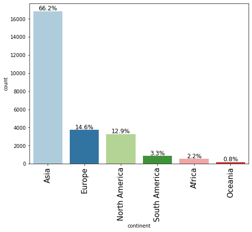

```python
labeled_barplot(data, "continent", perc=True)
```

- ~65 percent of applicants are from Asia, ~15% from Europe, and ~13% from other parts of North America.
- Oceania is the least represented continent.

**Observations on education_of_employee:**

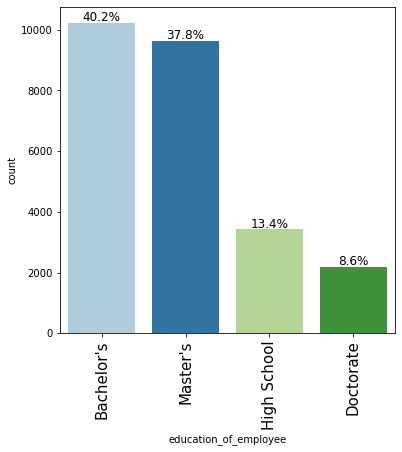

```python
labeled_barplot(data, "education_of_employee", perc=True)
```

- Only 13.4% of applicants don't have some form of higher education.

**Observations on has_job_experience:**

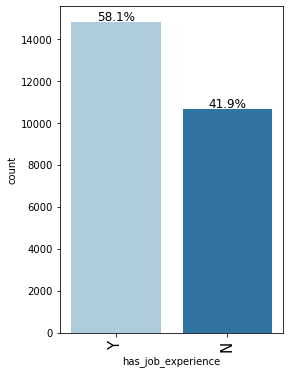

```python
labeled_barplot(data, "has_job_experience", perc=True)
```

- 58.1% of applicants have job experience and 41.9% of employees do not.

**Observations on requires_job_training:**

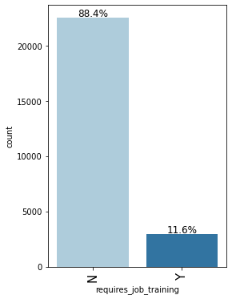

```python
labeled_barplot(data, "requires_job_training", perc=True)
```

**Observations on no_of_employees:**

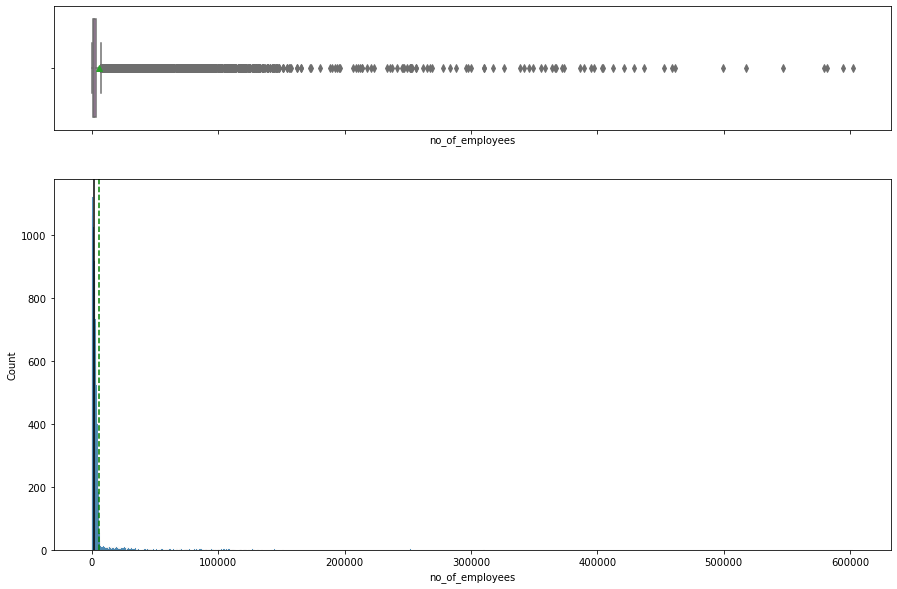

```python
histogram_boxplot(data,'no_of_employees')
```

- Almost all of the data is in a very small sliver of the histogram. That is likely because there is a huge difference between the 75th percentile (~ 3,500) and the max (~ 600,000+).
- As evident in the boxplot, there are more outliers in the upper whisker than we can count. This will have to be treated later.

**Observations on yr_of_estab:**

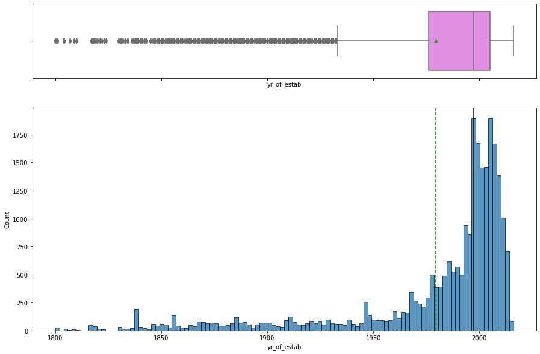

```python
histogram_boxplot(data,'yr_of_estab')
```

- There are many outliers in the lower whisker of the histogram.
- The histogram is heavily left-skewed.
- The mode is close the year 2000.

**Observations on region_of_employment:**

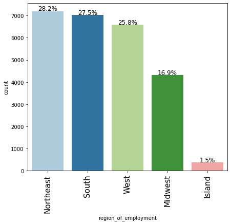

```python
labeled_barplot(data, "region_of_employment", perc=True)
```

- The most common regions of employment are the Northeast, followed closely by the South and West.
- The least represent region of employment is islands.

**Observations of prevailing_wage:**

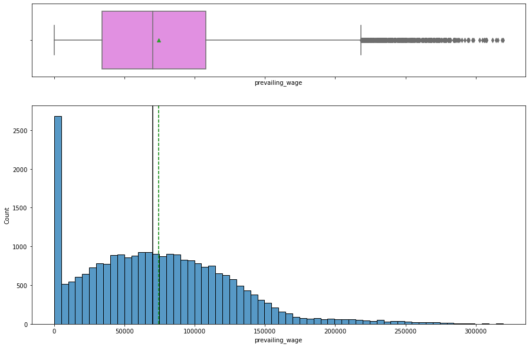

```python
histogram_boxplot(data,'prevailing_wage')
```

- Because the unit of prevailing wage is not consistent, there are many outliers in the upper whisker. Rather than treat these as outliers right away, we will have to convert all of the data to the same unit and then treat outliers.
- The mean in the histogram is not useful because of the above.

**Observations on unit_of_wage:**

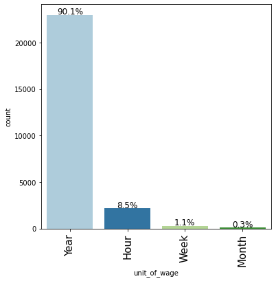

```python
labeled_barplot(data, "unit_of_wage", perc=True)
```

- Over 90% of the prevailing wages are yearly.

**Observations on full_time_position:**

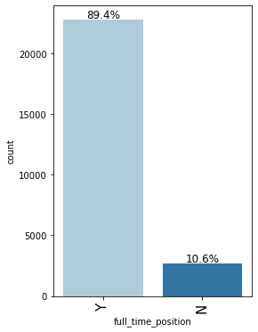

```python
labeled_barplot(data, "full_time_position", perc=True)
```

- 89.4 % of applicants are seeking full time positions and 10.6 are not.

**Observations on case_status:**

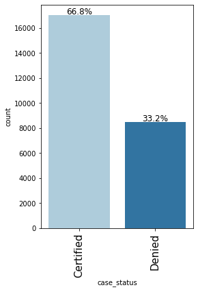

```python
labeled_barplot(data, "case_status", perc=True)
```

- 66.8% of applications are certified and 33.2% are denied.

**Bivariate Analysis:**

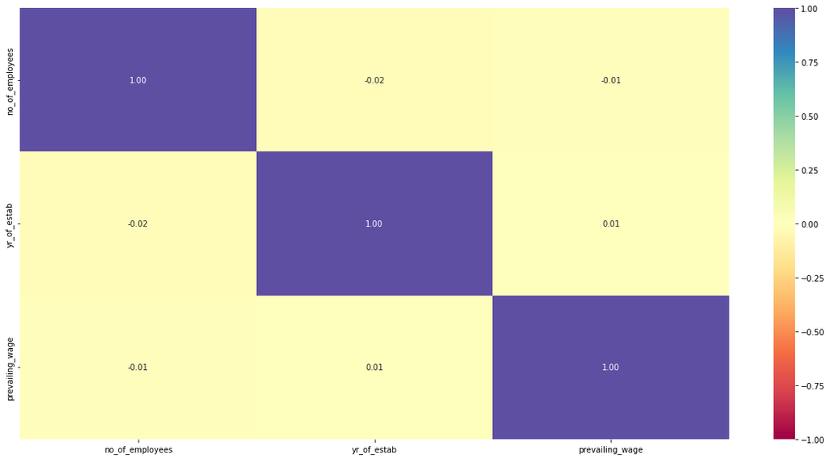

```python
# check the correlation between numerical variables:
plt.figure(figsize=(20,10))
sns.heatmap(data.corr(),annot=True,vmin=-1,vmax=1,fmt='.2f',cmap="Spectral")
plt.show()
```

- Strong correlation between numerical variables do not exist. That makes sense because the number of employees and year of establishment of a company is not likely to affect the prevailing wage of an employee's industry.

**Case_status vs. education_of_employee:**

```
case_status            Certified  Denied    All
education_of_employee
All                        17018    8462  25480
Bachelor's                  6367    3867  10234
High School                 1164    2256   3420
Master's                    7575    2059   9634
Doctorate                   1912     280   2192
------------------------------------------------------------------------------------------------------------------------
```

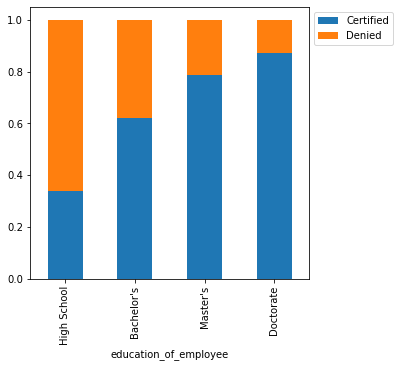

```python
stacked_barplot(data, "education_of_employee", "case_status")
```

- As the level of education increases among applicants, so does the likelihood of certification.
- Still, a decent amount of applicants with only high school degrees were certified (1,164).

**Case_status vs. has_job_experience:**

```
case_status         Certified  Denied    All
has_job_experience
All                     17018    8462  25480
N                        5994    4684  10678
Y                       11024    3778  14802
------------------------------------------------------------------------------------------------------------------------
```

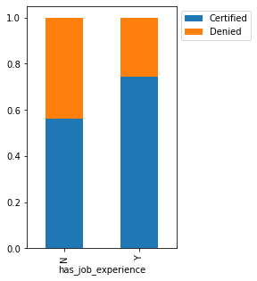

```python
stacked_barplot(data, "has_job_experience", "case_status")
```

- Applicants with prior job experience have ~20% greater chance of being certified.

**Case_status vs. continent:**

```
case_status    Certified  Denied    All
continent
All                17018    8462  25480
Asia               11012    5849  16861
North America       2037    1255   3292
Europe              2957     775   3732
South America        493     359    852
Africa               397     154    551
Oceania              122      70    192
------------------------------------------------------------------------------------------------------------------------
```

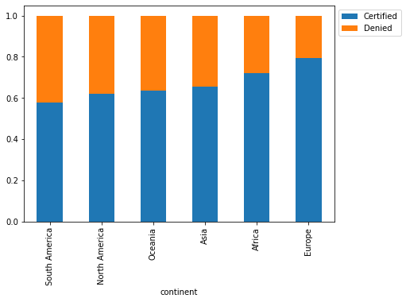

```python
stacked_barplot(data, "continent", "case_status")
```

- All continents see over 50% of their applicants be accepted.

**Case_status vs. requires_job_training:**

```
case_status            Certified  Denied    All
requires_job_training
All                        17018    8462  25480
N                          15012    7513  22525
Y                           2006     949   2955
------------------------------------------------------------------------------------------------------------------------
```

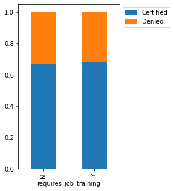

```python
stacked_barplot(data, "requires_job_training", "case_status")
```

- Whether or not the applicant requires job training does not correlate with certification.

**Case_status vs. yr_of_estab:**

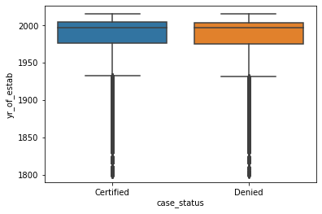

```python
sns.boxplot(data['case_status'],data['yr_of_estab'])
plt.show()
```

- There doesn't appear to be much relation between the case_status and the year of establishment of the applicant's company.

**Case_status vs. no_of_employees:**

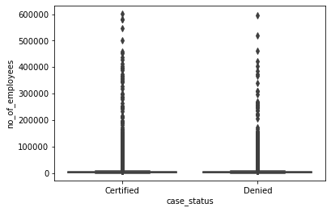

```python
sns.boxplot(data['case_status'],data['no_of_employees'])
plt.show()
```

- There doesn't appear to be much relation between the case_status and the number of employees at the applicant's company.

**Case_status vs. unit_of_wage:**

```
case_status   Certified  Denied    All
unit_of_wage
All               17018    8462  25480
Year              16047    6915  22962
Hour                747    1410   2157
Week                169     103    272
Month                55      34     89
------------------------------------------------------------------------------------------------------------------------
```

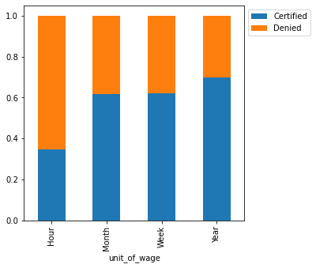

```python
stacked_barplot(data, "unit_of_wage", "case_status")
```

- Employees who are salaried appear to have a higher chance of certification than hourly employees.

**Case_status vs. prevailing_wage:**

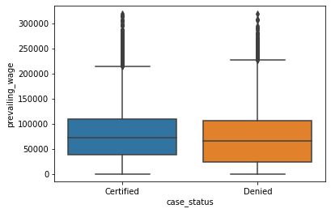

```python
sns.boxplot(data['case_status'],data['prevailing_wage'])
plt.show()
```

- The prevailing wage does not appear significantly higher in certified applications than denied applications.

## Data Preprocessing

- Missing value treatment (if needed)
- Feature engineering
- Outlier detection and treatment (if needed)
- Preparing data for modeling
- Any other preprocessing steps (if needed)

```python
data.head()
```

|  | continent | education_of_employee | has_job_experience | requires_job_training | no_of_employees | yr_of_estab | region_of_employment | prevailing_wage | unit_of_wage | full_time_position | case_status |
| --- | --- | --- | --- | --- | --- | --- | --- | --- | --- | --- | --- |
| 0 | Asia | High School | N | N | 14513 | 2007 | West | 592.2029 | Hour | Y | Denied |
| 1 | Asia | Master's | Y | N | 2412 | 2002 | Northeast | 83425.6500 | Year | Y | Certified |
| 2 | Asia | Bachelor's | N | Y | 44444 | 2008 | West | 122996.8600 | Year | Y | Denied |
| 3 | Asia | Bachelor's | N | N | 98 | 1897 | West | 83434.0300 | Year | Y | Denied |
| 4 | Africa | Master's | Y | N | 1082 | 2005 | South | 149907.3900 | Year | Y | Certified |

```python
# As we saw earlier, there are no missing values and missing value treatment is not necessary. However, we do need to address the varying units in prevailing_wage and outliers in other categories.

def adjust_wage(x):
    if x['unit_of_wage'] == 'Month':
        return x['prevailing_wage'] * 12
    if x['unit_of_wage'] == 'Week':
        return x['prevailing_wage'] * 49
    if x['unit_of_wage'] == 'Hour':
        return x['prevailing_wage'] * 2080
    if x['unit_of_wage'] == 'Year':
        return x['prevailing_wage']

data['prevailing_wage_adjusted'] = data.apply(adjust_wage, axis=1)
```

```python
data.head()
```

|  | continent | education_of_employee | has_job_experience | requires_job_training | no_of_employees | yr_of_estab | region_of_employment | prevailing_wage | unit_of_wage | full_time_position | case_status | prevailing_wage_adjusted |
| --- | --- | --- | --- | --- | --- | --- | --- | --- | --- | --- | --- | --- |
| 0 | Asia | High School | N | N | 14513 | 2007 | West | 592.2029 | Hour | Y | Denied | 1231782.032 |
| 1 | Asia | Master's | Y | N | 2412 | 2002 | Northeast | 83425.6500 | Year | Y | Certified | 83425.650 |
| 2 | Asia | Bachelor's | N | Y | 44444 | 2008 | West | 122996.8600 | Year | Y | Denied | 122996.860 |
| 3 | Asia | Bachelor's | N | N | 98 | 1897 | West | 83434.0300 | Year | Y | Denied | 83434.030 |
| 4 | Africa | Master's | Y | N | 1082 | 2005 | South | 149907.3900 | Year | Y | Certified | 149907.390 |

The prevailing wage adjustment appears to have been successful. Now we can drop the prevailing_wage column and unit_of_wage column.

```python
data.drop(['prevailing_wage', 'unit_of_wage'],axis=1,inplace=True)
```

**Outlier detection and treatment:**

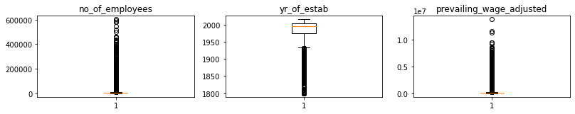

```python
# outlier detection using boxplot
numeric_columns = data.select_dtypes(include=np.number).columns.tolist()


plt.figure(figsize=(15, 12))

for i, variable in enumerate(numeric_columns):
    plt.subplot(6, 4, i + 1)
    plt.boxplot(data[variable], whis=1.5)
    plt.tight_layout()
    plt.title(variable)

plt.show()
```

```python
data.describe().T
```

|  | count | mean | std | min | 25% | 50% | 75% | max |
| --- | --- | --- | --- | --- | --- | --- | --- | --- |
| no_of_employees | 25480.0 | 5667.043210 | 22877.928848 | -26.0 | 1022.000 | 2109.00 | 3504.000 | 602069.00 |
| yr_of_estab | 25480.0 | 1979.409929 | 42.366929 | 1800.0 | 1976.000 | 1997.00 | 2005.000 | 2016.00 |
| prevailing_wage_adjusted | 25480.0 | 194649.586753 | 552873.248294 | 100.0 | 47107.965 | 82839.46 | 124825.035 | 13728621.55 |

```python
def treat_outliers(df, col):
    """
    Treats outliers in a variable

    df: dataframe
    col: dataframe column
    """
    Q1 = df[col].quantile(0.25)  # 25th quantile
    Q3 = df[col].quantile(0.75)  # 75th quantile
    IQR = Q3 - Q1
    Lower_Whisker = Q1 - 1.5 * IQR
    Upper_Whisker = Q3 + 1.5 * IQR

    # all the values smaller than Lower_Whisker will be assigned the value of Lower_Whisker
    # all the values greater than Upper_Whisker will be assigned the value of Upper_Whisker
    df[col] = np.clip(df[col], Lower_Whisker, Upper_Whisker)

    return df
```

```python
treat_outliers(data, 'no_of_employees')
treat_outliers(data, 'prevailing_wage_adjusted')
```

|  | continent | education_of_employee | has_job_experience | requires_job_training | no_of_employees | yr_of_estab | region_of_employment | full_time_position | case_status | prevailing_wage_adjusted |
| --- | --- | --- | --- | --- | --- | --- | --- | --- | --- | --- |
| 0 | Asia | High School | N | N | 7227.0 | 2007 | West | Y | Denied | 241400.64 |
| 1 | Asia | Master's | Y | N | 2412.0 | 2002 | Northeast | Y | Certified | 83425.65 |
| 2 | Asia | Bachelor's | N | Y | 7227.0 | 2008 | West | Y | Denied | 122996.86 |
| 3 | Asia | Bachelor's | N | N | 98.0 | 1897 | West | Y | Denied | 83434.03 |
| 4 | Africa | Master's | Y | N | 1082.0 | 2005 | South | Y | Certified | 149907.39 |
| ... | ... | ... | ... | ... | ... | ... | ... | ... | ... | ... |
| 25475 | Asia | Bachelor's | Y | Y | 2601.0 | 2008 | South | Y | Certified | 77092.57 |
| 25476 | Asia | High School | Y | N | 3274.0 | 2006 | Northeast | Y | Certified | 241400.64 |
| 25477 | Asia | Master's | Y | N | 1121.0 | 1910 | South | N | Certified | 146298.85 |
| 25478 | Asia | Master's | Y | Y | 1918.0 | 1887 | West | Y | Certified | 86154.77 |
| 25479 | Asia | Bachelor's | Y | N | 3195.0 | 1960 | Midwest | Y | Certified | 70876.91 |

25480 rows × 10 columns

```python
data['case_status'] = data['case_status'].apply(lambda x : 1 if x=='Certified' else 0)
```

```python
X = data.drop(['case_status'],axis=1)
y = data['case_status']

X = pd.get_dummies(X,drop_first=True)
```

## EDA

- It is a good idea to explore the data once again after manipulating it.

```python
X.head()
```

|  | no_of_employees | yr_of_estab | prevailing_wage_adjusted | continent_Asia | continent_Europe | continent_North America | continent_Oceania | continent_South America | education_of_employee_Doctorate | education_of_employee_High School | education_of_employee_Master's | has_job_experience_Y | requires_job_training_Y | region_of_employment_Midwest | region_of_employment_Northeast | region_of_employment_South | region_of_employment_West | full_time_position_Y |
| --- | --- | --- | --- | --- | --- | --- | --- | --- | --- | --- | --- | --- | --- | --- | --- | --- | --- | --- |
| 0 | 7227.0 | 2007 | 241400.64 | 1 | 0 | 0 | 0 | 0 | 0 | 1 | 0 | 0 | 0 | 0 | 0 | 0 | 1 | 1 |
| 1 | 2412.0 | 2002 | 83425.65 | 1 | 0 | 0 | 0 | 0 | 0 | 0 | 1 | 1 | 0 | 0 | 1 | 0 | 0 | 1 |
| 2 | 7227.0 | 2008 | 122996.86 | 1 | 0 | 0 | 0 | 0 | 0 | 0 | 0 | 0 | 1 | 0 | 0 | 0 | 1 | 1 |
| 3 | 98.0 | 1897 | 83434.03 | 1 | 0 | 0 | 0 | 0 | 0 | 0 | 0 | 0 | 0 | 0 | 0 | 0 | 1 | 1 |
| 4 | 1082.0 | 2005 | 149907.39 | 0 | 0 | 0 | 0 | 0 | 0 | 0 | 1 | 1 | 0 | 0 | 0 | 1 | 0 | 1 |

Categorical variables have been converted properly.

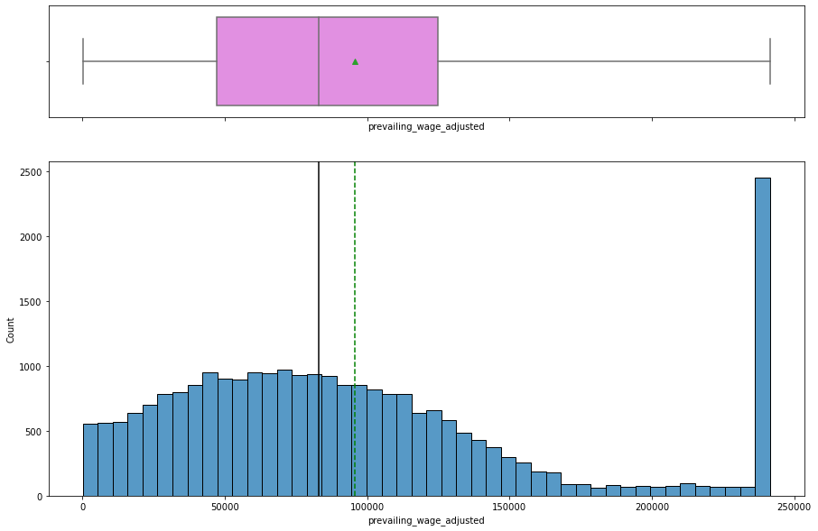

```python
histogram_boxplot(data,'prevailing_wage_adjusted')
```

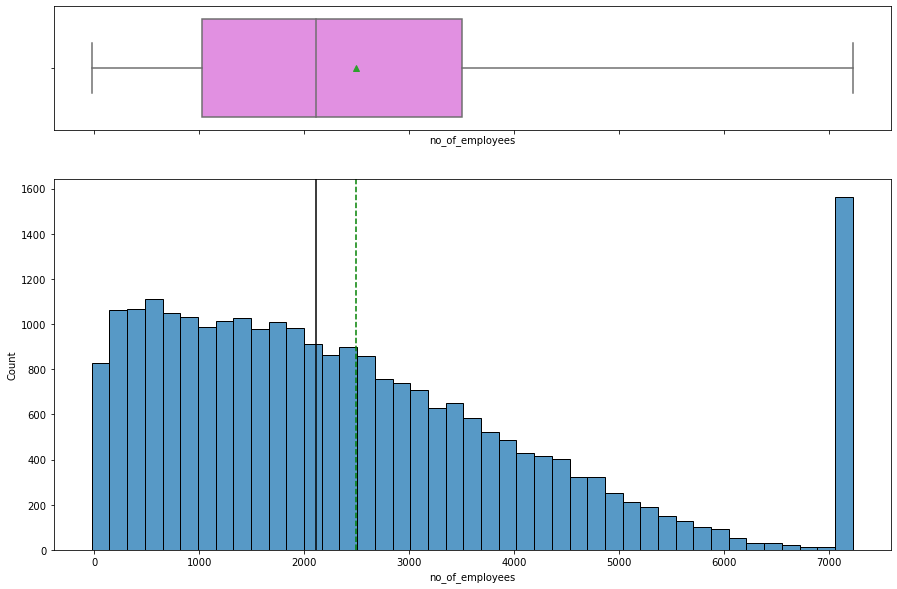

```python
histogram_boxplot(data,'no_of_employees')
```

## Building bagging and boosting models

```python
# Splitting data into training and test set:
X_train, X_test, y_train, y_test =train_test_split(X, y, test_size=0.3, random_state=1,stratify=y)
print(X_train.shape, X_test.shape)
```

```
(17836, 18) (7644, 18)
```

```python
y.value_counts(1)
```

```
1    0.667896
0    0.332104
Name: case_status, dtype: float64
```

```python
y_test.value_counts(1)
```

[output not shown]

```python
# defining a function to compute different metrics to check performance of a classification model built using sklearn
def model_performance_classification_sklearn(model, predictors, target):
    """
    Function to compute different metrics to check classification model performance

    model: classifier
    predictors: independent variables
    target: dependent variable
    """

    # predicting using the independent variables
    pred = model.predict(predictors)

    acc = accuracy_score(target, pred)  # to compute Accuracy
    recall = recall_score(target, pred)  # to compute Recall
    precision = precision_score(target, pred)  # to compute Precision
    f1 = f1_score(target, pred)  # to compute F1-score

    # creating a dataframe of metrics
    df_perf = pd.DataFrame(
        {
            "Accuracy": acc,
            "Recall": recall,
            "Precision": precision,
            "F1": f1,
        },
        index=[0],
    )

    return df_perf
```

```python
def confusion_matrix_sklearn(model, predictors, target):
    """
    To plot the confusion_matrix with percentages

    model: classifier
    predictors: independent variables
    target: dependent variable
    """
    y_pred = model.predict(predictors)
    cm = confusion_matrix(target, y_pred)
    labels = np.asarray(
        [
            ["{0:0.0f}".format(item) + "\n{0:.2%}".format(item / cm.flatten().sum())]
            for item in cm.flatten()
        ]
    ).reshape(2, 2)

    plt.figure(figsize=(6, 4))
    sns.heatmap(cm, annot=labels, fmt="")
    plt.ylabel("True label")
    plt.xlabel("Predicted label")
```

**Decision Tree:**

```python
# specify class weight to match the ratio of Denied:Certified
dtree = DecisionTreeClassifier(criterion='gini',class_weight={0:0.33,1:0.67},random_state=1)
```

```python
dtree.fit(X_train, y_train)
```

```
DecisionTreeClassifier(class_weight={0: 0.33, 1: 0.67}, random_state=1)
```

```python
confusion_matrix_sklearn(dtree, X_train, y_train)
```

[output not shown]

```python
dtree_model_train_perf=model_performance_classification_sklearn(dtree, X_train, y_train)
print("Training performance \n",dtree_model_train_perf)
```

```
Training performance
    Accuracy  Recall  Precision   F1
0       1.0     1.0        1.0  1.0
```

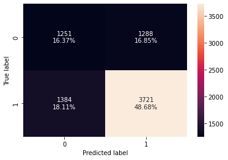

```python
confusion_matrix_sklearn(dtree, X_test, y_test)
```

```python
dtree_model_test_perf=model_performance_classification_sklearn(dtree, X_test, y_test)
print("Testing performance \n",dtree_model_test_perf)
```

```
Testing performance
    Accuracy    Recall  Precision        F1
0  0.650445  0.728893   0.742863  0.735812
```

- The decision tree appears to be overfitting the training data. The accuracy, recall, and precision are 1.0 for the training data, while those values range between .65-.73 on the test data.

**Bagging Classifier:**

```python
bagging = BaggingClassifier(random_state=1)
bagging.fit(X_train,y_train)
```

```
BaggingClassifier(random_state=1)
```

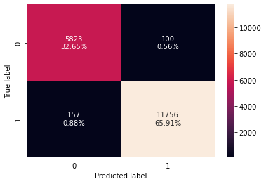

```python
confusion_matrix_sklearn(bagging, X_train, y_train)
```

```python
bagging_model_train_perf=model_performance_classification_sklearn(bagging, X_train, y_train)
print("Training performance \n",bagging_model_train_perf)
```

```
Training performance
    Accuracy    Recall  Precision        F1
0  0.985591  0.986821   0.991565  0.989188
```

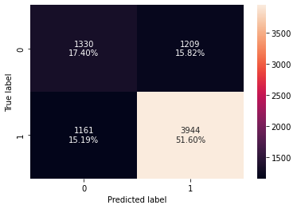

```python
confusion_matrix_sklearn(bagging, X_test, y_test)
```

```python
bagging_model_test_perf=model_performance_classification_sklearn(bagging, X_test, y_test)
print("Testing performance \n",bagging_model_test_perf)
```

```
Testing performance
    Accuracy    Recall  Precision        F1
0  0.689953  0.772576   0.765379  0.768961
```

**Bagging Classifier with weighted decision tree:**

```python
bagging_wt = BaggingClassifier(base_estimator=DecisionTreeClassifier(criterion='gini',class_weight={0:0.33,1:0.67},random_state=1),random_state=1)
bagging_wt.fit(X_train,y_train)
```

```
BaggingClassifier(base_estimator=DecisionTreeClassifier(class_weight={0: 0.33,
                                                                      1: 0.67},
                                                        random_state=1),
                  random_state=1)
```

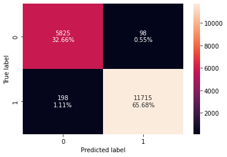

```python
confusion_matrix_sklearn(bagging_wt,X_train,y_train)
```

```python
bagging_wt_model_train_perf=model_performance_classification_sklearn(bagging_wt,X_train,y_train)
print("Training performance \n",bagging_wt_model_train_perf)
```

```
Training performance
    Accuracy   Recall  Precision        F1
0  0.983404  0.98338   0.991704  0.987524
```

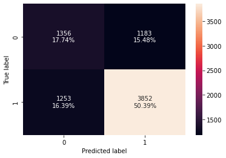

```python
confusion_matrix_sklearn(bagging_wt,X_test,y_test)
```

```python
bagging_wt_model_test_perf=model_performance_classification_sklearn(bagging_wt, X_test, y_test)
print("Testing performance \n",bagging_wt_model_test_perf)
```

```
Testing performance
    Accuracy    Recall  Precision        F1
0  0.681319  0.754554   0.765045  0.759763
```

- Adding a class weight does not seem particularly helpful, as the F1 has decreased slightly.

**Random Forest:**

```python
rf = RandomForestClassifier(random_state=1)
rf.fit(X_train,y_train)
```

```
RandomForestClassifier(random_state=1)
```

```python
confusion_matrix_sklearn(rf,X_train,y_train)
```

[output not shown]

```python
rf_model_train_perf=model_performance_classification_sklearn(rf,X_train,y_train)
print("Training performance \n",rf_model_train_perf)
```

```
Training performance
    Accuracy  Recall  Precision   F1
0       1.0     1.0        1.0  1.0
```

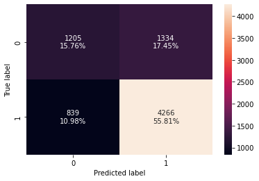

```python
confusion_matrix_sklearn(rf,X_test,y_test)
```

```python
rf_model_test_perf=model_performance_classification_sklearn(rf,X_test,y_test)
print("Testing performance \n",rf_model_test_perf)
```

```
Testing performance
    Accuracy    Recall  Precision        F1
0  0.715725  0.835651   0.761786  0.797011
```

- The random forest also overfits but it appears to generalize better to the test data than the other three models, with an F1 score near .8.